# Risk Factor Analysis

## Outcome Variable

**Outcome Variable:** wast_rec90d

## Predictor Variables

**Intervention Variable:** nrooms

**Adjustment Set:**

unadjusted

## Stratifying Variables

The analysis was stratified on these variable(s):

- agecat
- studyid
- country

## Data Summary

| agecat | studyid | country | nrooms | wast_rec90d | n_cell | n |
| --- | --- | --- | --- | --- | --- | --- |
| 0-24 months | CMC-V-BCS-2002 | INDIA | 4+ | 0 | 2 | 324 |
| 0-24 months | CMC-V-BCS-2002 | INDIA | 4+ | 1 | 4 | 324 |
| 0-24 months | CMC-V-BCS-2002 | INDIA | 1 | 0 | 75 | 324 |
| 0-24 months | CMC-V-BCS-2002 | INDIA | 1 | 1 | 124 | 324 |
| 0-24 months | CMC-V-BCS-2002 | INDIA | 2 | 0 | 32 | 324 |
| 0-24 months | CMC-V-BCS-2002 | INDIA | 2 | 1 | 54 | 324 |
| 0-24 months | CMC-V-BCS-2002 | INDIA | 3 | 0 | 11 | 324 |
| 0-24 months | CMC-V-BCS-2002 | INDIA | 3 | 1 | 22 | 324 |
| 0-24 months | COHORTS | INDIA | 4+ | 0 | 13 | 1959 |
| 0-24 months | COHORTS | INDIA | 4+ | 1 | 4 | 1959 |
| 0-24 months | COHORTS | INDIA | 1 | 0 | 1079 | 1959 |
| 0-24 months | COHORTS | INDIA | 1 | 1 | 319 | 1959 |
| 0-24 months | COHORTS | INDIA | 2 | 0 | 373 | 1959 |
| 0-24 months | COHORTS | INDIA | 2 | 1 | 125 | 1959 |
| 0-24 months | COHORTS | INDIA | 3 | 0 | 34 | 1959 |
| 0-24 months | COHORTS | INDIA | 3 | 1 | 12 | 1959 |
| 0-24 months | CONTENT | PERU | 4+ | 0 | 1 | 7 |
| 0-24 months | CONTENT | PERU | 4+ | 1 | 4 | 7 |
| 0-24 months | CONTENT | PERU | 1 | 0 | 0 | 7 |
| 0-24 months | CONTENT | PERU | 1 | 1 | 2 | 7 |
| 0-24 months | CONTENT | PERU | 2 | 0 | 0 | 7 |
| 0-24 months | CONTENT | PERU | 2 | 1 | 0 | 7 |
| 0-24 months | CONTENT | PERU | 3 | 0 | 0 | 7 |
| 0-24 months | CONTENT | PERU | 3 | 1 | 0 | 7 |
| 0-24 months | GMS-Nepal | NEPAL | 4+ | 0 | 152 | 643 |
| 0-24 months | GMS-Nepal | NEPAL | 4+ | 1 | 162 | 643 |
| 0-24 months | GMS-Nepal | NEPAL | 1 | 0 | 18 | 643 |
| 0-24 months | GMS-Nepal | NEPAL | 1 | 1 | 33 | 643 |
| 0-24 months | GMS-Nepal | NEPAL | 2 | 0 | 62 | 643 |
| 0-24 months | GMS-Nepal | NEPAL | 2 | 1 | 55 | 643 |

[output cut: 306 more lines]

The following strata were considered:

- agecat: 0-24 months, studyid: CMC-V-BCS-2002, country: INDIA
- agecat: 0-24 months, studyid: COHORTS, country: INDIA
- agecat: 0-24 months, studyid: CONTENT, country: PERU
- agecat: 0-24 months, studyid: GMS-Nepal, country: NEPAL
- agecat: 0-24 months, studyid: IRC, country: INDIA
- agecat: 0-24 months, studyid: MAL-ED, country: BANGLADESH
- agecat: 0-24 months, studyid: MAL-ED, country: BRAZIL
- agecat: 0-24 months, studyid: MAL-ED, country: INDIA
- agecat: 0-24 months, studyid: MAL-ED, country: NEPAL
- agecat: 0-24 months, studyid: MAL-ED, country: PERU
- agecat: 0-24 months, studyid: MAL-ED, country: SOUTH AFRICA
- agecat: 0-24 months, studyid: MAL-ED, country: TANZANIA, UNITED REPUBLIC OF
- agecat: 0-24 months, studyid: NIH-Crypto, country: BANGLADESH
- agecat: 0-24 months, studyid: PROVIDE, country: BANGLADESH
- agecat: 0-6 months, studyid: CMC-V-BCS-2002, country: INDIA
- agecat: 0-6 months, studyid: COHORTS, country: INDIA
- agecat: 0-6 months, studyid: CONTENT, country: PERU
- agecat: 0-6 months, studyid: GMS-Nepal, country: NEPAL
- agecat: 0-6 months, studyid: IRC, country: INDIA
- agecat: 0-6 months, studyid: MAL-ED, country: BANGLADESH
- agecat: 0-6 months, studyid: MAL-ED, country: BRAZIL
- agecat: 0-6 months, studyid: MAL-ED, country: INDIA
- agecat: 0-6 months, studyid: MAL-ED, country: NEPAL
- agecat: 0-6 months, studyid: MAL-ED, country: PERU
- agecat: 0-6 months, studyid: MAL-ED, country: SOUTH AFRICA
- agecat: 0-6 months, studyid: MAL-ED, country: TANZANIA, UNITED REPUBLIC OF
- agecat: 0-6 months, studyid: NIH-Crypto, country: BANGLADESH
- agecat: 0-6 months, studyid: PROVIDE, country: BANGLADESH
- agecat: 6-24 months, studyid: CMC-V-BCS-2002, country: INDIA
- agecat: 6-24 months, studyid: COHORTS, country: INDIA
- agecat: 6-24 months, studyid: CONTENT, country: PERU
- agecat: 6-24 months, studyid: GMS-Nepal, country: NEPAL
- agecat: 6-24 months, studyid: IRC, country: INDIA
- agecat: 6-24 months, studyid: MAL-ED, country: BANGLADESH
- agecat: 6-24 months, studyid: MAL-ED, country: BRAZIL
- agecat: 6-24 months, studyid: MAL-ED, country: INDIA
- agecat: 6-24 months, studyid: MAL-ED, country: NEPAL
- agecat: 6-24 months, studyid: MAL-ED, country: PERU
- agecat: 6-24 months, studyid: MAL-ED, country: SOUTH AFRICA
- agecat: 6-24 months, studyid: MAL-ED, country: TANZANIA, UNITED REPUBLIC OF
- agecat: 6-24 months, studyid: NIH-Crypto, country: BANGLADESH
- agecat: 6-24 months, studyid: PROVIDE, country: BANGLADESH

### Dropped Strata

Some strata were dropped due to rare outcomes:

- agecat: 0-24 months, studyid: CMC-V-BCS-2002, country: INDIA
- agecat: 0-24 months, studyid: COHORTS, country: INDIA
- agecat: 0-24 months, studyid: CONTENT, country: PERU
- agecat: 0-24 months, studyid: MAL-ED, country: BANGLADESH
- agecat: 0-24 months, studyid: MAL-ED, country: BRAZIL
- agecat: 0-24 months, studyid: MAL-ED, country: INDIA
- agecat: 0-24 months, studyid: MAL-ED, country: NEPAL
- agecat: 0-24 months, studyid: MAL-ED, country: PERU
- agecat: 0-24 months, studyid: MAL-ED, country: SOUTH AFRICA
- agecat: 0-24 months, studyid: MAL-ED, country: TANZANIA, UNITED REPUBLIC OF
- agecat: 0-24 months, studyid: PROVIDE, country: BANGLADESH
- agecat: 0-6 months, studyid: CMC-V-BCS-2002, country: INDIA
- agecat: 0-6 months, studyid: COHORTS, country: INDIA
- agecat: 0-6 months, studyid: CONTENT, country: PERU
- agecat: 0-6 months, studyid: IRC, country: INDIA
- agecat: 0-6 months, studyid: MAL-ED, country: BANGLADESH
- agecat: 0-6 months, studyid: MAL-ED, country: BRAZIL
- agecat: 0-6 months, studyid: MAL-ED, country: INDIA
- agecat: 0-6 months, studyid: MAL-ED, country: NEPAL
- agecat: 0-6 months, studyid: MAL-ED, country: PERU
- agecat: 0-6 months, studyid: MAL-ED, country: SOUTH AFRICA
- agecat: 0-6 months, studyid: MAL-ED, country: TANZANIA, UNITED REPUBLIC OF
- agecat: 0-6 months, studyid: NIH-Crypto, country: BANGLADESH
- agecat: 0-6 months, studyid: PROVIDE, country: BANGLADESH
- agecat: 6-24 months, studyid: CMC-V-BCS-2002, country: INDIA
- agecat: 6-24 months, studyid: COHORTS, country: INDIA
- agecat: 6-24 months, studyid: CONTENT, country: PERU
- agecat: 6-24 months, studyid: IRC, country: INDIA
- agecat: 6-24 months, studyid: MAL-ED, country: BANGLADESH
- agecat: 6-24 months, studyid: MAL-ED, country: BRAZIL
- agecat: 6-24 months, studyid: MAL-ED, country: INDIA
- agecat: 6-24 months, studyid: MAL-ED, country: NEPAL
- agecat: 6-24 months, studyid: MAL-ED, country: PERU
- agecat: 6-24 months, studyid: MAL-ED, country: SOUTH AFRICA
- agecat: 6-24 months, studyid: MAL-ED, country: TANZANIA, UNITED REPUBLIC OF
- agecat: 6-24 months, studyid: NIH-Crypto, country: BANGLADESH
- agecat: 6-24 months, studyid: PROVIDE, country: BANGLADESH

## Methods Detail

We’re interested in the causal parameters $E[Y_a]$ for all values of $a \in \mathcal{A}$. These parameters represent the mean outcome if, possibly contrary to fact, we intervened to set all units to have $A=a$. Under the randomization and positivity assumptions, these are identified by the statistical parameters $\psi_a=E_W[E_{Y|A,W}(Y|A=a,W)]$. In addition, we’re interested in the mean of $Y$, $E[Y]$ under no intervention (the observed mean). We will estimate these parameters by using SuperLearner to fit the relevant likelihood factors – $E_{Y|A,W}(Y|A=a,W)$ and $p(A=a|W)$, and then updating our likelihood fit using a joint TMLE.

For unadjusted analyses ($W=\{\}$), initial likelihoods were estimated using Lrnr_glm to estimate the simple $E(Y|A)$ and Lrnr_mean to estimate $p(A)$. For adjusted analyses, a small library containing Lrnr_glmnet, Lrnr_xgboost, and Lrnr_mean was used.

Having estimated these parameters, we will then use the delta method to estimate relative risks and attributable risks relative to a prespecified baseline level of $A$.

# Results Detail

## Results Plots

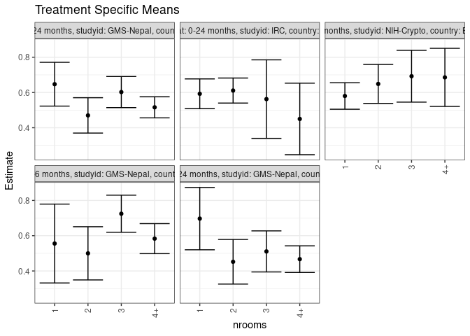

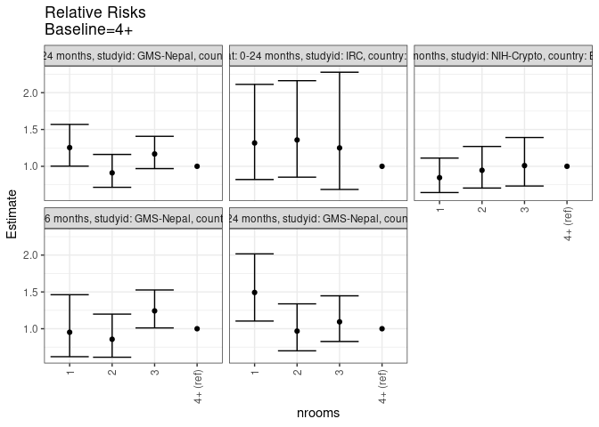

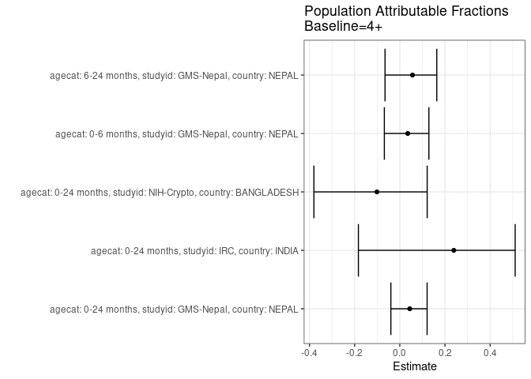

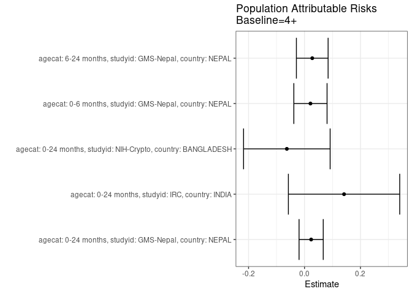

## Results Table

### Parameter: TSM

| agecat | studyid | country | intervention_level | baseline_level | estimate | ci_lower | ci_upper |
| --- | --- | --- | --- | --- | --- | --- | --- |
| 0-24 months | GMS-Nepal | NEPAL | 4+ | NA | 0.5159236 | 0.4561954 | 0.5756518 |
| 0-24 months | GMS-Nepal | NEPAL | 1 | NA | 0.6470588 | 0.5229282 | 0.7711895 |
| 0-24 months | GMS-Nepal | NEPAL | 2 | NA | 0.4700855 | 0.3697893 | 0.5703817 |
| 0-24 months | GMS-Nepal | NEPAL | 3 | NA | 0.6024845 | 0.5143128 | 0.6906561 |
| 0-24 months | IRC | INDIA | 4+ | NA | 0.4500000 | 0.2471890 | 0.6528110 |
| 0-24 months | IRC | INDIA | 1 | NA | 0.5925926 | 0.5081592 | 0.6770260 |
| 0-24 months | IRC | INDIA | 2 | NA | 0.6111111 | 0.5401543 | 0.6820679 |
| 0-24 months | IRC | INDIA | 3 | NA | 0.5625000 | 0.3398407 | 0.7851593 |
| 0-24 months | NIH-Crypto | BANGLADESH | 4+ | NA | 0.6857143 | 0.5209342 | 0.8504944 |
| 0-24 months | NIH-Crypto | BANGLADESH | 1 | NA | 0.5802469 | 0.5049956 | 0.6554982 |
| 0-24 months | NIH-Crypto | BANGLADESH | 2 | NA | 0.6486486 | 0.5382188 | 0.7590785 |
| 0-24 months | NIH-Crypto | BANGLADESH | 3 | NA | 0.6923077 | 0.5453040 | 0.8393114 |
| 0-6 months | GMS-Nepal | NEPAL | 4+ | NA | 0.5833333 | 0.4981147 | 0.6685520 |
| 0-6 months | GMS-Nepal | NEPAL | 1 | NA | 0.5555556 | 0.3318457 | 0.7792654 |
| 0-6 months | GMS-Nepal | NEPAL | 2 | NA | 0.5000000 | 0.3491063 | 0.6508937 |
| 0-6 months | GMS-Nepal | NEPAL | 3 | NA | 0.7246377 | 0.6194642 | 0.8298111 |
| 6-24 months | GMS-Nepal | NEPAL | 4+ | NA | 0.4670330 | 0.3913393 | 0.5427267 |
| 6-24 months | GMS-Nepal | NEPAL | 1 | NA | 0.6969697 | 0.5201686 | 0.8737708 |
| 6-24 months | GMS-Nepal | NEPAL | 2 | NA | 0.4520548 | 0.3254929 | 0.5786167 |
| 6-24 months | GMS-Nepal | NEPAL | 3 | NA | 0.5108696 | 0.3944329 | 0.6273063 |

### Parameter: E(Y)

| agecat | studyid | country | intervention_level | baseline_level | estimate | ci_lower | ci_upper |
| --- | --- | --- | --- | --- | --- | --- | --- |
| 0-24 months | GMS-Nepal | NEPAL | NA | NA | 0.5396579 | 0.4973524 | 0.5819633 |
| 0-24 months | IRC | INDIA | NA | NA | 0.5913706 | 0.5391835 | 0.6435576 |
| 0-24 months | NIH-Crypto | BANGLADESH | NA | NA | 0.6225806 | 0.5684562 | 0.6767051 |
| 0-6 months | GMS-Nepal | NEPAL | NA | NA | 0.6045627 | 0.5449300 | 0.6641955 |
| 6-24 months | GMS-Nepal | NEPAL | NA | NA | 0.4947368 | 0.4401559 | 0.5493178 |

### Parameter: RR

| agecat | studyid | country | intervention_level | baseline_level | estimate | ci_lower | ci_upper |
| --- | --- | --- | --- | --- | --- | --- | --- |
| 0-24 months | GMS-Nepal | NEPAL | 4+ | 4+ | 1.0000000 | 1.0000000 | 1.000000 |
| 0-24 months | GMS-Nepal | NEPAL | 1 | 4+ | 1.2541757 | 1.0023703 | 1.569237 |
| 0-24 months | GMS-Nepal | NEPAL | 2 | 4+ | 0.9111533 | 0.7147455 | 1.161533 |
| 0-24 months | GMS-Nepal | NEPAL | 3 | 4+ | 1.1677785 | 0.9689629 | 1.407388 |
| 0-24 months | IRC | INDIA | 4+ | 4+ | 1.0000000 | 1.0000000 | 1.000000 |
| 0-24 months | IRC | INDIA | 1 | 4+ | 1.3168724 | 0.8208567 | 2.112614 |
| 0-24 months | IRC | INDIA | 2 | 4+ | 1.3580247 | 0.8527213 | 2.162759 |
| 0-24 months | IRC | INDIA | 3 | 4+ | 1.2500000 | 0.6860395 | 2.277566 |
| 0-24 months | NIH-Crypto | BANGLADESH | 4+ | 4+ | 1.0000000 | 1.0000000 | 1.000000 |
| 0-24 months | NIH-Crypto | BANGLADESH | 1 | 4+ | 0.8461934 | 0.6440264 | 1.111823 |
| 0-24 months | NIH-Crypto | BANGLADESH | 2 | 4+ | 0.9459459 | 0.7046622 | 1.269848 |
| 0-24 months | NIH-Crypto | BANGLADESH | 3 | 4+ | 1.0096154 | 0.7326591 | 1.391265 |
| 0-6 months | GMS-Nepal | NEPAL | 4+ | 4+ | 1.0000000 | 1.0000000 | 1.000000 |
| 0-6 months | GMS-Nepal | NEPAL | 1 | 4+ | 0.9523810 | 0.6205522 | 1.461649 |
| 0-6 months | GMS-Nepal | NEPAL | 2 | 4+ | 0.8571429 | 0.6129707 | 1.198579 |
| 0-6 months | GMS-Nepal | NEPAL | 3 | 4+ | 1.2422360 | 1.0110429 | 1.526296 |
| 6-24 months | GMS-Nepal | NEPAL | 4+ | 4+ | 1.0000000 | 1.0000000 | 1.000000 |
| 6-24 months | GMS-Nepal | NEPAL | 1 | 4+ | 1.4923351 | 1.1042417 | 2.016827 |
| 6-24 months | GMS-Nepal | NEPAL | 2 | 4+ | 0.9679291 | 0.7002806 | 1.337873 |
| 6-24 months | GMS-Nepal | NEPAL | 3 | 4+ | 1.0938619 | 0.8268902 | 1.447029 |

### Parameter: PAR

| agecat | studyid | country | intervention_level | baseline_level | estimate | ci_lower | ci_upper |
| --- | --- | --- | --- | --- | --- | --- | --- |
| 0-24 months | GMS-Nepal | NEPAL | 4+ | NA | 0.0237343 | -0.0195251 | 0.0669937 |
| 0-24 months | IRC | INDIA | 4+ | NA | 0.1413706 | -0.0576416 | 0.3403827 |
| 0-24 months | NIH-Crypto | BANGLADESH | 4+ | NA | -0.0631336 | -0.2179095 | 0.0916422 |
| 0-6 months | GMS-Nepal | NEPAL | 4+ | NA | 0.0212294 | -0.0381741 | 0.0806329 |
| 6-24 months | GMS-Nepal | NEPAL | 4+ | NA | 0.0277039 | -0.0289729 | 0.0843807 |

### Parameter: PAF

| agecat | studyid | country | intervention_level | baseline_level | estimate | ci_lower | ci_upper |
| --- | --- | --- | --- | --- | --- | --- | --- |
| 0-24 months | GMS-Nepal | NEPAL | 4+ | NA | 0.0439802 | -0.0396218 | 0.1208594 |
| 0-24 months | IRC | INDIA | 4+ | NA | 0.2390558 | -0.1833208 | 0.5106685 |
| 0-24 months | NIH-Crypto | BANGLADESH | 4+ | NA | -0.1014064 | -0.3803220 | 0.1211500 |
| 0-6 months | GMS-Nepal | NEPAL | 4+ | NA | 0.0351153 | -0.0684841 | 0.1286698 |
| 6-24 months | GMS-Nepal | NEPAL | 4+ | NA | 0.0559972 | -0.0654705 | 0.1636171 |